# Lab 11: Corridors and Least-Cost Paths

### *Exercise 2*

1. *Create a new map of the resistance surface using a new, distinct c value (NOT c = 4) with an informative title, and plot it side by side with the previous (c = 4) resistance surface. The new c value should be different enough to have a visible difference between the two maps. (3 pts)*

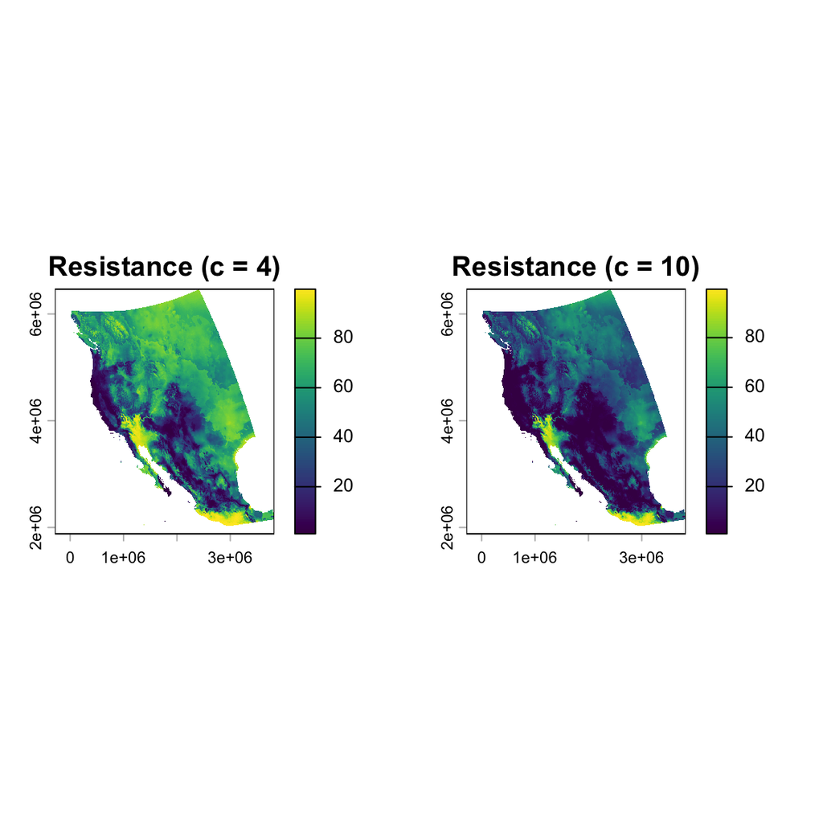

```r
c.par <- 4
# generate resistance surface
resistance <- 100 - 99 * ((1 - exp(-c.par * future.proj)) / (1 - exp(-c.par)))

# transform to conductance surface
conductance <- 1 / resistance

# generate the cost surface
cs <- create_cs(x = conductance, neighbours = 16)

#par(mfrow=c(1,3))

#par(mfrow=c(1,1))


c.par2 <- 10
# generate resistance surface
resistance2 <- 100 - 99 * ((1 - exp(-c.par2 * future.proj)) / (1 - exp(-c.par2)))


# transform to conductance surface
conductance <- 1 / resistance

# generate the cost surface
cs <- create_cs(x = conductance, neighbours = 16)


#par(mfrow=c(1,3))

par(mfrow=c(1,2))
plot(resistance, main = "Resistance (c = 4)")
plot(resistance2, main = "Resistance (c = 10)")
```

2. *Describe the difference in the resistance surface between the two values of c (c=4 and whichever you picked). How did the resistance surface change, and what does that imply about the species’ biology or their relationship between suitability values and movement? (4 pts)*

The difference between the two values is that c=10 showed a less resistant surface than c=4. This implies that the species is more of a generalist and can move through less suitable environments.

3. *Choose a value for c that make the most sense for your species and state your reasoning. If you’re working on the kit fox data, explain why c=4 makes sense. If you want to use a new value of c for the rest of the lab, copy and paste the `cost-surface` chunk below, with a new name, and edit to use your new c value. (NOTE: don’t just edit that chunk above, or that will ruin your map for 2.1!) (2 pts)*

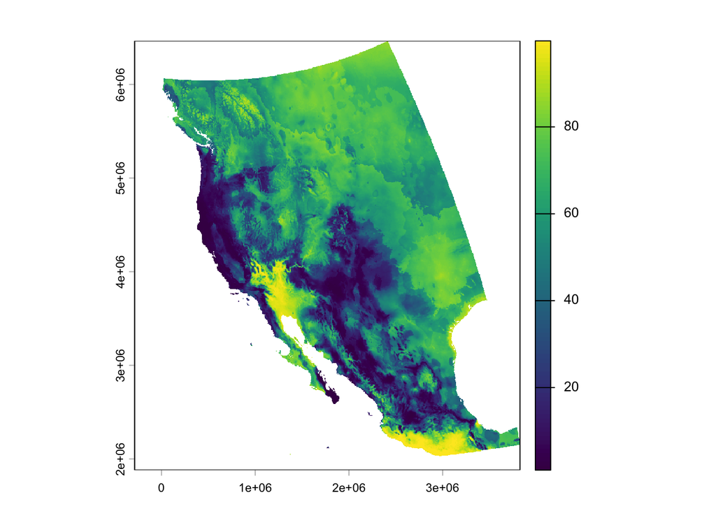

```r
c.par3 <- 4
# generate resistance surface
resistance3 <- 100 - 99 * ((1 - exp(-c.par3 * future.proj)) / (1 - exp(-c.par3)))


# transform to conductance surface
conductance <- 1 / resistance

# generate the cost surfac6
cs.6 <- create_cs(x = conductance, neighbours = 16)

plot(resistance3)
```

## Least-cost path and cost corridor

Now that we have the cost surface, we can find the cheapest route from the source to the destination. `create_lcp()` finds the least-cost path, and `create_cost_corridor()` calculates, for every cell, the combined cost of the best route from the source to that cell and on to the destination. Cells with low values lie on or near a good route. To turn that surface into a corridor, we keep the cells whose cost is within 5% of the cheapest possible.

```r
# least-cost path (the result is converted to a terra vector with vect())
lcp <- create_lcp(x = cs.6, origin = src.xy, destination = dest.xy,
                  cost_distance = TRUE, check_locations = TRUE)
lcp.vect <- vect(lcp)
as.data.frame(lcp.vect)          # includes the accumulated cost of the path
```

```
##   costFunction fromCell toCell     cost
## 1           NA   849706 863027 399.1982
```

```r
# length of the path, the straight-line distance between the two points, and the ratio
path.km <- sum(perim(lcp.vect)) / 1000
straight.km <- sqrt(sum((src.xy - dest.xy)^2)) / 1000
path.km
```

```
## [1] 214.6625
```

```r
straight.km
```

```
## [1] 179.6886
```

```r
path.km / straight.km
```

```
## [1] 1.194636
```

Take a moment to consider what that ratio of the LCP distance and the straight line distance represents. Was it very easy for your species to get from the source to the destination point?

```r
# cost corridor: keep cells within 5% of the cheapest possible cost
corridor <- create_cost_corridor(x = cs.6, origin = src.xy, destination = dest.xy)
min.cost <- global(corridor, "min", na.rm = TRUE)[1, 1]
corridor.zone <- ifel(corridor <= min.cost * 1.05, 1, NA)

# How big is the corridor?
corridor.km2 <- global(corridor.zone, "notNA")[1, 1] * prod(res(current.proj)) / 1e6
corridor.km2
```

```
## [1] 10608
```

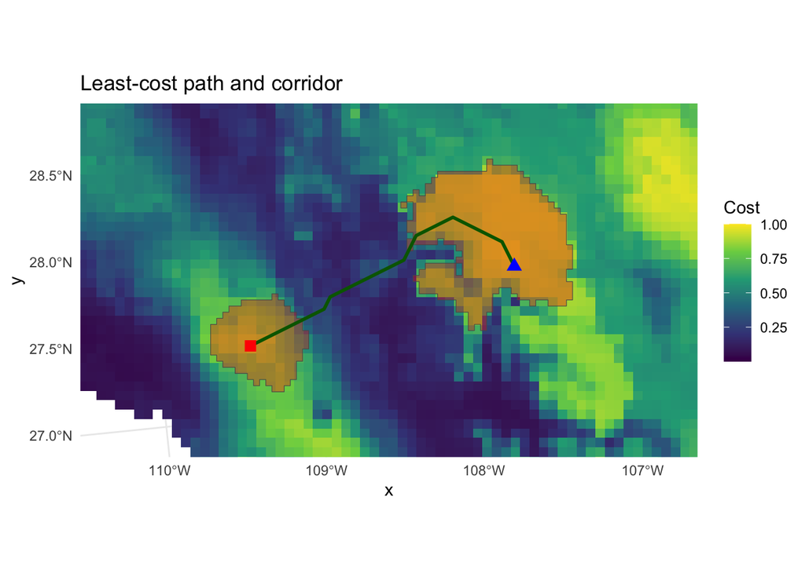

```r
library(ggplot2)
library(tidyterra)

ggplot() +
  geom_spatraster(data = future.proj) +
  scale_fill_viridis_c(na.value = "transparent", name = "Cost") +
  geom_spatvector(data = as.polygons(corridor.zone), fill = "red", alpha = 0.35, na.rm = TRUE) +
  geom_spatvector(data = lcp.vect, color = "darkgreen", linewidth = 1) +
  geom_point(data = as.data.frame(src.xy), aes(x = x, y = y), shape = 17, color = "blue", size = 3) +
  geom_point(data = as.data.frame(dest.xy), aes(x = x, y = y), shape = 15, color = "red", size = 3) +
  labs(title = "Least-cost path and corridor") +
  theme_minimal() +
  coord_sf(xlim = c(ext(lcp.vect)[1] * 0.95, ext(lcp.vect)[2] * 1.05),
           ylim = c(ext(lcp.vect)[3] * 0.98, ext(lcp.vect)[4] * 1.02))
```

**A sanity check:** the path should mostly follow cells with higher suitability. If it cuts straight through the poorest habitat, check that you passed *conductance* (not resistance) to `create_cs()`.

### *Exercise 3*

1. *Report the length of the least-cost path (km), the straight-line distance between the source and destination (km), the ratio of the two, and the area of the corridor (km²). (2 pts)*

Least cost path: 214.6625 km Straight: Line Distance 179.6886 km Ratio: 1.194636 km Area of the corridor: 10608 km2

2. *Describe what the path passes through. Does it stay mostly in moderate to high suitability, or does it cross poor areas? What does the ratio of path length to straight-line distance tell you? (2 pts)*

The path passes through an area of poor suitability. The ratio of path length and straight line distance tell me that the path of least resistance was only 19% longer than the straight line path.

## Adding human development

The SDM was built from climate alone, so it knows nothing about the things that most limit dispersal for many animals: roads, cities, and farmland. The **human footprint index** (Venter et al.) combines built-up areas, population density, power infrastructure, cropland, pasture, roads, railways, and waterways into a single score from 0 (low) to 50 (high pressure) at about 1 km resolution. Let’s add it to the resistance surface.

The file is global, so the first download may take a few minutes. We crop it to your study region, project it onto the same grid as your resistance surface, and rescale it to 0-1. Then we **add** it to the resistance: the most heavily developed cells gain +100, making them as hard to cross as the worst natural habitat.

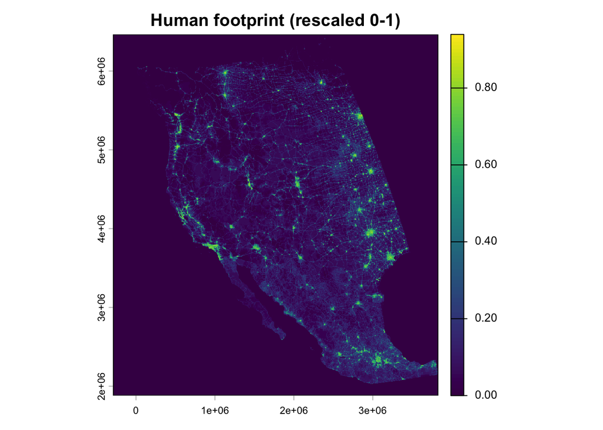

```r
footprint <- geodata::footprint(year = 2009, path = "data")

fp <- crop(footprint, ext(current.suit))
fp.proj <- project(fp, current.proj, method = "average")   # average the finer cells within each coarser cell
fp.proj[is.na(fp.proj)] <- 0
fp.scaled <- clamp(fp.proj / 50, 0, 1)
plot(fp.scaled, main = "Human footprint (rescaled 0-1)")
```

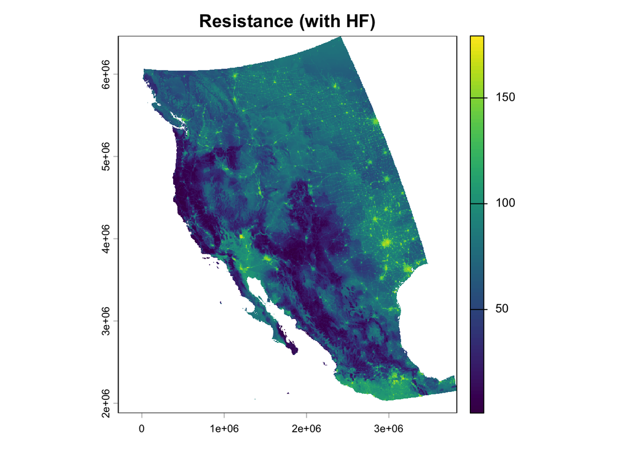

```r
resistance.hf <- resistance3 + 100 * fp.scaled
plot(resistance.hf, main = "Resistance (with HF)")
```

This weighting (+100) is an assumption for illustration. A different weight would change the result, and a real analysis would need to justify it. Now repeat the analysis with the new surface:

```r
cs.hf <- create_cs(x = 1 / resistance.hf, neighbours = 16)

lcp.hf <- create_lcp(x = cs.hf, origin = src.xy, destination = dest.xy,
                     cost_distance = TRUE, check_locations = TRUE)
lcp.hf.vect <- vect(lcp.hf)

corridor.hf <- create_cost_corridor(x = cs.hf, origin = src.xy, destination = dest.xy)
min.cost.hf <- global(corridor.hf, "min", na.rm = TRUE)[1, 1]
corridor.hf.zone <- ifel(corridor.hf <= min.cost.hf * 1.05, 1, NA)

sum(perim(lcp.hf.vect)) / 1000       # length of the new path (km)
```

```
## [1] 197.4866
```

### *Exercise 4*

1. *Create a map showing both least-cost paths (suitability only, and suitability plus human footprint) on top of the human footprint layer, with a title and legend. I’ve gotten it started for you below. (5 pts)*

```
## <SpatRaster> resampled to 500490 cells.
```

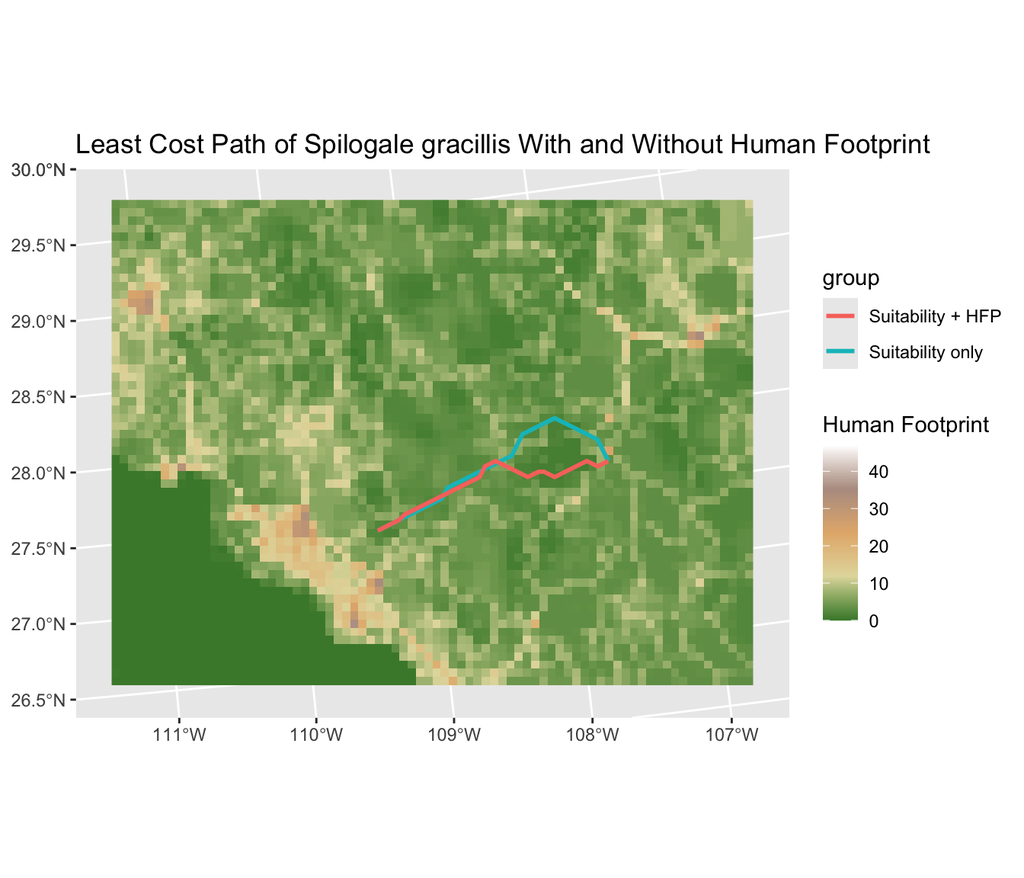

```r
lcp.lines <- rbind(lcp.vect, lcp.hf.vect)  # combine the two lines into one spatVector object!
lcp.lines$group <- c("Suitability only", "Suitability + HFP")

#fp.scaled.vect<- vect(fp.scaled)

ggplot() +
  geom_spatraster(data = fp.proj) +
  scale_fill_whitebox_c(name = "Human Footprint") +
  xlim(c(1650166, 2134166)) + ylim(c(2985874, 3357874)) +
  geom_spatvector(data = lcp.lines, aes(color = group), linewidth = 1)+
  labs(title = "Least Cost Path of Spilogale gracillis With and Without Human Footprint")
```

```r
#SpatExtent : 1851166.6877896572, 2023166.6877896572, 3106874.055720252, 3226874.055720252 (xmin, xmax, ymin, ymax)
  #plot(fp.scaled, main = "Human footprint (rescaled 0-1)")
```

2. *In 3-4 sentences, describe how adding the human footprint changed the route (both in length, shape, and conceptually) and which version you think is more realistic for your species, and why. (4 pts)*

Adding the human footprint actually shortened the length of the path. The original path was 214.7 km and the path with human footprint came out to be 197.5km. The suitability + HFP might actually create a more suitable path that would hypothetically eliminate some competition and land barriers such as elevation. I think the suitability + HFP path is more realistic for my species because they don’t tend to avoid human prensence as much due to their generalist nature, at times they can benefit from it.

## Interpreting your corridor

### *Exercise 5*

1. *Look up a published dispersal distance for your species (or a close relative) and cite your source. Compare it to the length of your preferred least-cost path. Could an individual plausibly make this trip, and over how many dispersal events or generations might it take? How confident are you in this corridor, given all the data we put in? (4 pts)*

Wesley A. Brashear, Loren K. Ammerman, Robert C. Dowler, Short-distance dispersal and lack of genetic structure in an urban striped skunk population, Journal of Mammalogy, Volume 96, Issue 1, 15 February 2015, Pages 72–80, https://doi.org/10.1093/jmammal/gyu004

## Extra credit: all-pairs least-cost paths

```r
top.current <- head(patch.sizes$value[order(patch.sizes$count, decreasing = TRUE)], 3)
top.gain    <- head(gain.sizes$value[order(gain.sizes$count, decreasing = TRUE)], 3)

locs <- rbind(get.best.cells(current.patches, current.proj, top.current),
              get.best.cells(gain.patches, future.proj, top.gain))
```

### *Extra credit*

*Remove `eval=FALSE`, and use the functions `create_FETE_lcps()` and `create_lcp_density()` to calculate the paths between all pairs of points and combine them into a density map, adn then plot the map with the point locations overlaid and an informative title. In 2-3 sentences, describe where movement concentrates and how this compares to your single least-cost path. (+3 pts)*

### *Exercise 6*

*Reflect on today’s lab. (3 pts)*

I enjoyed today’s lab and evaluating the LCPs of the western spotted skunk. I found including the human footprint and its alternative path particularly interestng. This lab seemed to go by smoother than past labs.